# problem3.7

## Scatterplot matrix

Here I plot the continuous variables

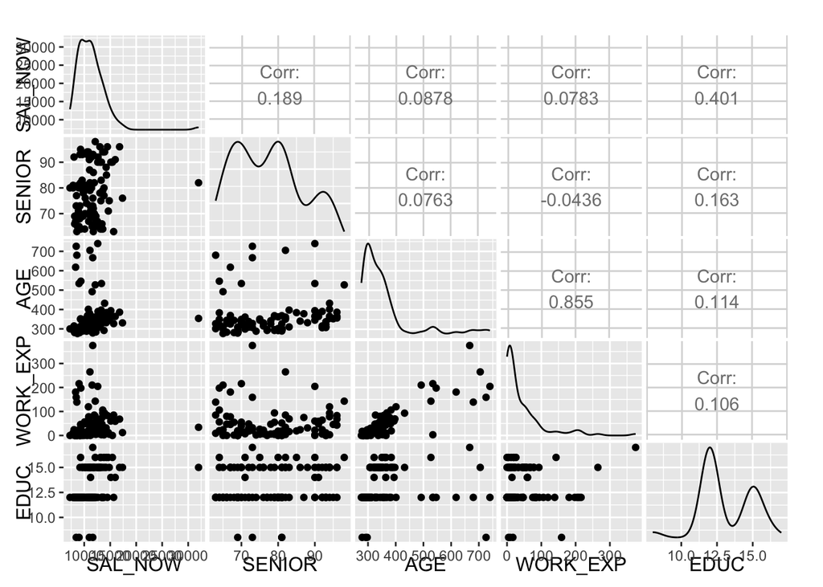

```r
ggpairs(wages[,c("SAL_NOW","SENIOR","AGE","WORK_EXP","EDUC")], corSize = 1)
```

# [Assumptions of linear regression](https://www.statisticssolutions.com/assumptions-of-multiple-linear-regression)

- Linear relationship.
- Multivariate normality.
- No or little multicollinearity.
- No auto-correlation.
- Homoscedasticity.

## A full lm model

Starting salary `SAL_START` might be a good leading indicator of current salary but it is not an *independent* variable, but an other dependent variable. It should not be used in the regression.

```r
mod1 <- lm(SAL_NOW ~ sex + AGE + SENIOR + WORK_EXP + EDUC + HS_GRAD + COLLEGE + COLL_GRAD + GRAD_SCH, data=wages)
summary(mod1)
```

```
##
## Call:
## lm(formula = SAL_NOW ~ sex + AGE + SENIOR + WORK_EXP + EDUC +
##     HS_GRAD + COLLEGE + COLL_GRAD + GRAD_SCH, data = wages)
##
## Residuals:
##     Min      1Q  Median      3Q     Max
## -4099.7 -1353.6  -276.3   958.0 18029.2
##
## Coefficients:
##              Estimate Std. Error t value Pr(>|t|)
## (Intercept)  7842.652  12641.166   0.620 0.536322
## sexMale      2600.370    678.872   3.830 0.000217 ***
## AGE             5.034      5.745   0.876 0.382877
## SENIOR         26.097     24.801   1.052 0.295062
## WORK_EXP      -10.942     10.372  -1.055 0.293865
## EDUC         -161.708   1520.242  -0.106 0.915490
## HS_GRAD       551.701   6229.758   0.089 0.929600
## COLLEGE      2403.448  10674.663   0.225 0.822293
## COLL_GRAD    4286.337  12271.641   0.349 0.727566
## GRAD_SCH     5386.943  13918.163   0.387 0.699500
## ---
## Signif. codes:  0 '***' 0.001 '**' 0.01 '*' 0.05 '.' 0.1 ' ' 1
##
## Residual standard error: 2472 on 106 degrees of freedom
## Multiple R-squared:  0.3197, Adjusted R-squared:  0.2619
## F-statistic: 5.535 on 9 and 106 DF,  p-value: 3.115e-06
```

## Test for linear relationship

Let’s plot residuals vs fitted values

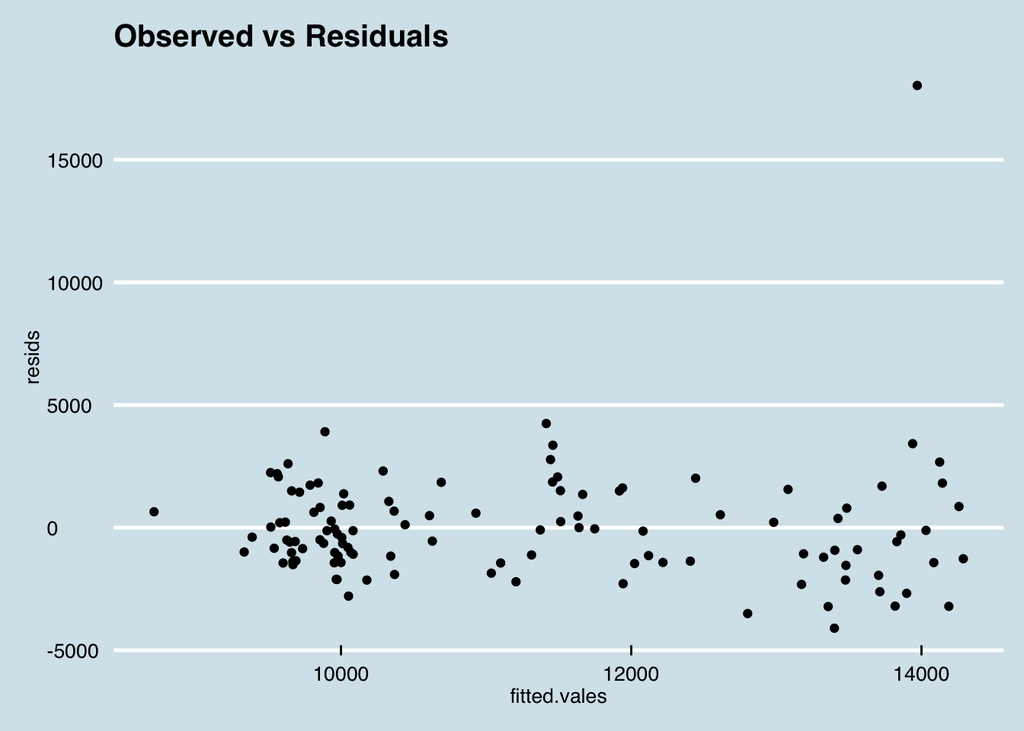

```r
choice_model <- mod1
choice_df <- wages
choice_df$resids <- resid(choice_model)
choice_df$fitted.vales <- choice_model$fitted.values

ggplot(choice_df,aes(fitted.vales, resids))+geom_point() + ggtitle("Observed vs Residuals")  + theme_economist() + scale_fill_economist()
```

Looks flat enough. The outlier is annoying me.

## Test for normality of residuals

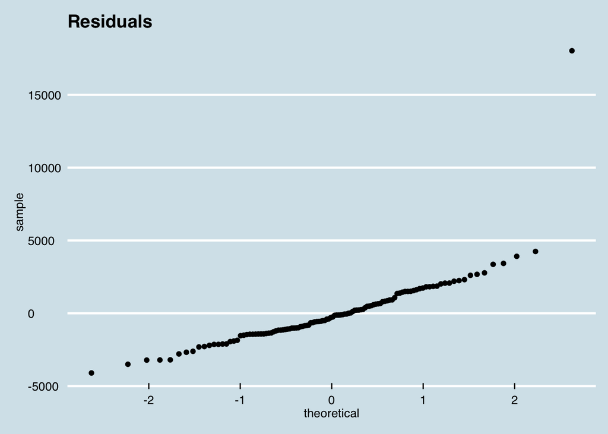

```r
ggplot(choice_df, aes(sample = resids)) + ggtitle("Residuals") + stat_qq()  + theme_economist() + scale_fill_economist()
```

```r
shapiro.test(choice_df$resids)
```

```
##
##  Shapiro-Wilk normality test
##
## data:  choice_df$resids
## W = 0.7369, p-value = 3.955e-13
```

Once again the outlier!

## Test for autocorrelation

We removed starting salary.

```r
durbinWatsonTest(choice_model)
```

```
##  lag Autocorrelation D-W Statistic p-value
##    1      -0.1424365      2.276732   0.136
##  Alternative hypothesis: rho != 0
```

## Testing for multicollinearity

Variance inflation factor test for multicollinearity - all should be under 2.

```r
sqrt(car::vif(choice_model))
```

```
##       sex       AGE    SENIOR  WORK_EXP      EDUC   HS_GRAD   COLLEGE
##  1.357465  2.375500  1.050313  2.771583 12.167337 13.439780 21.673675
## COLL_GRAD  GRAD_SCH
## 13.546387  5.605248
```

We’ve got trouble here. The education levels are redundant with each other, and exclusive education graduate levels are not appropriate for regression. Let’s assume everyone who finished college also finished high school, and create a dummy ordinal indicator for that measurement.

```r
wages$edu_level_text<-as.factor(ifelse(wages$GRAD_SCH==1,"GRAD_SCH",ifelse(wages$COLL_GRAD,"COLL_GRAD",ifelse(wages$COLLEGE,"SOME_COLLEGE",ifelse(wages$HS_GRAD,"HIGH_SCHOOL","GRAMMAR")))))
wages <- within(wages, edu_level_text <- relevel(edu_level_text, ref = 'GRAMMAR'))

wages$edu_level<-as.factor(ifelse(wages$GRAD_SCH==1,4,ifelse(wages$COLL_GRAD,3,ifelse(wages$COLLEGE,2,ifelse(wages$HS_GRAD,1,0)))))
```

## Remove the outlier

```r
remove_outlier_wages<-wages[-which(wages$SAL_NOW==max(wages$SAL_NOW)),]
mod2 <- lm(SAL_NOW ~ sex + AGE + SENIOR + WORK_EXP + EDUC, data=remove_outlier_wages)
summary(mod2)
```

```
##
## Call:
## lm(formula = SAL_NOW ~ sex + AGE + SENIOR + WORK_EXP + EDUC,
##     data = remove_outlier_wages)
##
## Residuals:
##     Min      1Q  Median      3Q     Max
## -3038.4 -1229.3  -269.6  1353.9  4522.7
##
## Coefficients:
##             Estimate Std. Error t value Pr(>|t|)
## (Intercept) 2067.759   1786.207   1.158    0.250
## sexMale     1775.829    404.845   4.386 2.67e-05 ***
## AGE            4.132      3.582   1.153    0.251
## SENIOR        26.567     17.563   1.513    0.133
## WORK_EXP      -6.349      5.743  -1.105    0.271
## EDUC         400.711     93.262   4.297 3.78e-05 ***
## ---
## Signif. codes:  0 '***' 0.001 '**' 0.01 '*' 0.05 '.' 0.1 ' ' 1
##
## Residual standard error: 1757 on 109 degrees of freedom
## Multiple R-squared:  0.3522, Adjusted R-squared:  0.3225
## F-statistic: 11.85 on 5 and 109 DF,  p-value: 3.639e-09
```

## Edulevel

```r
mod4 <- lm(SAL_NOW ~ sex + AGE + SENIOR + WORK_EXP + edu_level, data=remove_outlier_wages)
summary(mod4)
```

```
##
## Call:
## lm(formula = SAL_NOW ~ sex + AGE + SENIOR + WORK_EXP + edu_level,
##     data = remove_outlier_wages)
##
## Residuals:
##     Min      1Q  Median      3Q     Max
## -4019.4 -1149.9  -113.3   965.5  4395.0
##
## Coefficients:
##             Estimate Std. Error t value Pr(>|t|)
## (Intercept) 7359.081   1825.506   4.031 0.000105 ***
## sexMale     1980.395    463.838   4.270 4.28e-05 ***
## AGE            2.140      3.967   0.539 0.590684
## SENIOR        26.480     17.106   1.548 0.124603
## WORK_EXP      -4.313      7.159  -0.602 0.548164
## edu_level1   -75.825    894.888  -0.085 0.932635
## edu_level2  1050.249    937.312   1.120 0.265037
## edu_level3  3057.213   1050.131   2.911 0.004389 **
## edu_level4  2537.953   2409.368   1.053 0.294567
## ---
## Signif. codes:  0 '***' 0.001 '**' 0.01 '*' 0.05 '.' 0.1 ' ' 1
##
## Residual standard error: 1707 on 106 degrees of freedom
## Multiple R-squared:  0.4054, Adjusted R-squared:  0.3605
## F-statistic: 9.033 on 8 and 106 DF,  p-value: 2.174e-09
```

```r
choice_model<-mod4
```

## Goodness of fit comparison

```r
anova(mod2,mod4)
```

```
## Analysis of Variance Table
##
## Model 1: SAL_NOW ~ sex + AGE + SENIOR + WORK_EXP + EDUC
## Model 2: SAL_NOW ~ sex + AGE + SENIOR + WORK_EXP + edu_level
##   Res.Df       RSS Df Sum of Sq      F  Pr(>F)
## 1    109 336527061
## 2    106 308903748  3  27623313 3.1596 0.02772 *
## ---
## Signif. codes:  0 '***' 0.001 '**' 0.01 '*' 0.05 '.' 0.1 ' ' 1
```

## Drop AGE and WORK_EXP

```r
mod5 <- lm(SAL_NOW ~ sex +  SENIOR + edu_level, data=remove_outlier_wages)
summary(mod5)
```

```
##
## Call:
## lm(formula = SAL_NOW ~ sex + SENIOR + edu_level, data = remove_outlier_wages)
##
## Residuals:
##     Min      1Q  Median      3Q     Max
## -3977.0 -1114.2  -169.9   983.8  4455.7
##
## Coefficients:
##             Estimate Std. Error t value Pr(>|t|)
## (Intercept)  7837.79    1514.75   5.174 1.06e-06 ***
## sexMale      1832.94     386.74   4.740 6.57e-06 ***
## SENIOR         28.71      16.52   1.738  0.08511 .
## edu_level1   -130.08     875.71  -0.149  0.88219
## edu_level2   1055.36     923.79   1.142  0.25580
## edu_level3   3084.70    1040.24   2.965  0.00372 **
## edu_level4   1706.14    1894.72   0.900  0.36987
## ---
## Signif. codes:  0 '***' 0.001 '**' 0.01 '*' 0.05 '.' 0.1 ' ' 1
##
## Residual standard error: 1694 on 108 degrees of freedom
## Multiple R-squared:  0.4033, Adjusted R-squared:  0.3702
## F-statistic: 12.17 on 6 and 108 DF,  p-value: 2.05e-10
```

```r
choice_model<-mod5
```

## Goodness of fit comparison

```r
anova(mod2,mod5)
```

```
## Analysis of Variance Table
##
## Model 1: SAL_NOW ~ sex + AGE + SENIOR + WORK_EXP + EDUC
## Model 2: SAL_NOW ~ sex + SENIOR + edu_level
##   Res.Df       RSS Df Sum of Sq      F   Pr(>F)
## 1    109 336527061
## 2    108 309961553  1  26565508 9.2562 0.002947 **
## ---
## Signif. codes:  0 '***' 0.001 '**' 0.01 '*' 0.05 '.' 0.1 ' ' 1
```

## Retest

```r
sqrt(car::vif(mod4))
```

[output not shown]

```r
shapiro.test(resid(mod4))
```

```
##
##  Shapiro-Wilk normality test
##
## data:  resid(mod4)
## W = 0.97815, p-value = 0.05701
```

We reject the null hypothesis that sex is not a significant factor in current salary. Education level is also a significant factor.

### c. Examine the residuals from your regression model. Are there any influential observations in the data? What other concerns might you have about the model?

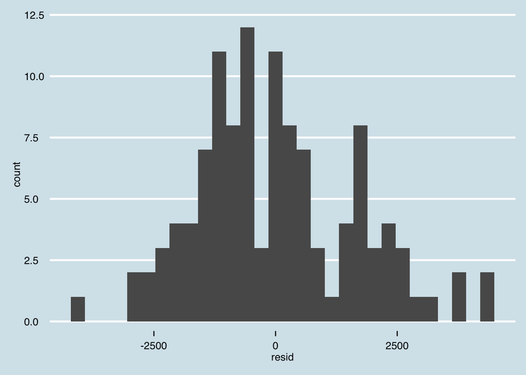

```r
remove_outlier_wages$resid<-resid(mod4)
ggplot(remove_outlier_wages,aes(x=resid))+geom_histogram()+ theme_economist() + scale_fill_economist()
```

I wonder if there is something in which lack of promotion also factors into ultimate salary. Do these assumptions hold up for old and young? ## 40 and over

```r
remove_outlier_wages %>% filter(AGE>=40*12) -> oldsters
mod6 <- lm(SAL_NOW ~ sex + AGE + SENIOR + WORK_EXP + edu_level, data=oldsters)
summary(mod6)
```

```
##
## Call:
## lm(formula = SAL_NOW ~ sex + AGE + SENIOR + WORK_EXP + edu_level,
##     data = oldsters)
##
## Residuals:
##          1          2          3          4          5          6
## -1.532e+03  1.532e+03  3.010e+02  1.892e+02  4.551e+02 -5.684e-14
##          7          8          9         10         11
## -5.684e-14 -4.504e+01 -9.003e+02  5.684e-14 -9.663e-13
##
## Coefficients:
##               Estimate Std. Error t value Pr(>|t|)
## (Intercept)  1171.8552  7968.7118   0.147    0.897
## sexMale       360.9957  2394.6451   0.151    0.894
## AGE            -5.6221    12.6495  -0.444    0.700
## SENIOR        156.4209    76.2270   2.052    0.177
## WORK_EXP       -0.3078    14.7960  -0.021    0.985
## edu_level1   1118.4309  2243.4395   0.499    0.668
## edu_level2   1146.7707  3289.7949   0.349    0.761
## edu_level3  -1374.2431  4367.5605  -0.315    0.783
## edu_level4   2914.7720  4435.3579   0.657    0.579
##
## Residual standard error: 1709 on 2 degrees of freedom
## Multiple R-squared:  0.8268, Adjusted R-squared:  0.134
## F-statistic: 1.193 on 8 and 2 DF,  p-value: 0.5327
```

## Under 40

```r
remove_outlier_wages %>% filter(AGE<40*12) -> youngsters
mod7 <- lm(SAL_NOW ~ sex + AGE + SENIOR + WORK_EXP + edu_level, data=youngsters)
summary(mod7)
```

```
##
## Call:
## lm(formula = SAL_NOW ~ sex + AGE + SENIOR + WORK_EXP + edu_level,
##     data = youngsters)
##
## Residuals:
##     Min      1Q  Median      3Q     Max
## -3923.9  -979.6  -281.4  1086.4  5150.9
##
## Coefficients:
##             Estimate Std. Error t value Pr(>|t|)
## (Intercept) 5376.953   3473.960   1.548    0.125
## sexMale      905.453    634.127   1.428    0.157
## AGE           18.652     14.911   1.251    0.214
## SENIOR        -3.685     22.935  -0.161    0.873
## WORK_EXP       4.935     14.214   0.347    0.729
## edu_level1  -874.861    996.011  -0.878    0.382
## edu_level2   -22.288   1135.687  -0.020    0.984
## edu_level3  1601.201   1497.491   1.069    0.288
##
## Residual standard error: 1660 on 96 degrees of freedom
## Multiple R-squared:  0.4515, Adjusted R-squared:  0.4115
## F-statistic: 11.29 on 7 and 96 DF,  p-value: 2.312e-10
```

If we look at the ages separately we fail to reject the null hypothesis of sex as a significant factor.